# Rose Notebook Proj 5 Wine

Rose Koh

- Discuss coef of models in regards to the number of stars and the wine label appeal.
- Not surprisingly, `STARS` and `LabelAppeal` appear to have a fairly strong positive correlation with the number of cases sold.
- We are expected to compare model to model and decide criteria for selecting the best count regression model (if the model seems counter intuitive, we must explain).
- We will use metrics such as AIC, average squared errors and explain how we can make inferences from the model, and discuss other relevant model output.

# What I found in data

- There are 12795 observations, 14 predictors and 1 response variable.
- There are some values such as: FixedAcidity, VolatileAcidity, CitricAcid, ResidualSugar, Chlorides, FreeSulfurDioxide, TotalSulfurDioxide, Sulphates, Alcohol, LabelAppeal
- After taking a closer look at these data points, it is likely that the creator of this dataset ended up standardizing the data.
- `LabelAppeal` and `STARS` to be factors as indicated by their descriptions. The rest of the predictors are continuous or discrete.
- Missing more than a quarter of all the `STARS` rankings (as much in test data too)
- Would remove the column if it wasn’t such a highly significant predictor!
- There are many observations that are missing multiple pieces of data. Is imputation good idea? It certainly doesn’t look like missing at random.
- To manage this (and because it appears that STARS rating is indeed predictive of selling and missing values are not random) we will simply assign NAs a 0.

# How I prepped data

Negative Values - Use absolute value - The alternative would be to center by adding the min of each variable * and impute the rest

DATA:

1. Data as is
2. Data by shifted by min value
3. Data by Jeremy’s method
4. Data by ABS and Log

# Build Negative binomial model

Negative binomial regression is an alternative when there is overdispersion (( var(Y_i) > E(Y_i) )).

“A Poisson distribution is parameterized by $\lambda$, which happens to be both its mean and variance. While convenient, it’s not often realistic. A distribution of counts will usually have a variance that’s not equal to its mean. When we see this happen with data that we assume is Poisson distributed, we say we have under- or overdispersion, depending on if the variance is smaller or larger than the mean. Performing Poisson regression on count data that exhibits this behavior results in a model that doesn’t fit well.”

“One approach that addresses this issue is the Negative Binomial Regresion. The negative binomial distribution describes the probabilities of the occurrence of whole numbers greater than or equal to 0. Unlike the Poisson distribution, the variance and the mean are not equivalent. This suggests it might serve as a useful approximation for modeling counts with variability different from its mean. The variance of a negative binomial distribution is a function of its mean and has an additional parameter `k` called the dispersion parameter. Say our count is a random variable Y from a negative binomial distribution, when the variance of Y is:”

$$var(Y) = \mu + \mu^2lk$$

“As the dispersion parameter gets larger and larger, the variance converges to the same value as the mean, and the negative binomial turns into a Poisson distribution.”

```
## [1] "TARGET mean: 3"
```

```
## [1] "TARGET variance: 3.711"
```

- It appears that there is a slight overdispersion with the variance greater than the mean as shown above.

## Negative Binomial Model - Rose

Build negative binomial model and select the predictors using stepAIC.

| Observations | 12795 |
| --- | --- |
| Dependent variable | TARGET |
| Type | Generalized linear model |
| Family | Negative Binomial(40840.67) |
| Link | log |

[output not shown]

|  | Est. | S.E. | z val. | p |
| --- | --- | --- | --- | --- |
| (Intercept) | 0.71 | 0.20 | 3.57 | 0.00 |
| Density | -0.27 | 0.19 | -1.41 | 0.16 |
| pH | -0.01 | 0.01 | -1.63 | 0.10 |
| Alcohol | 0.00 | 0.00 | 2.64 | 0.01 |
| LabelAppeal1 | 0.23 | 0.04 | 6.16 | 0.00 |
| LabelAppeal2 | 0.42 | 0.04 | 11.46 | 0.00 |
| LabelAppeal3 | 0.56 | 0.04 | 14.76 | 0.00 |
| LabelAppeal4 | 0.69 | 0.04 | 16.36 | 0.00 |
| AcidIndex | -0.08 | 0.00 | -17.35 | 0.00 |
| STARS1 | 0.77 | 0.02 | 39.18 | 0.00 |
| STARS2 | 1.08 | 0.02 | 59.37 | 0.00 |
| STARS3 | 1.20 | 0.02 | 62.65 | 0.00 |
| STARS4 | 1.32 | 0.02 | 54.45 | 0.00 |
| FixedAcidity | -0.00 | 0.00 | -0.04 | 0.97 |
| VolatileAcidity | -0.03 | 0.00 | -5.26 | 0.00 |
| CitricAcid | 0.01 | 0.00 | 1.22 | 0.22 |
| ResidualSugar | 0.00 | 0.00 | 0.51 | 0.61 |
| Chlorides | -0.03 | 0.01 | -2.42 | 0.02 |
| FreeSulfurDioxide | 0.00 | 0.00 | 2.76 | 0.01 |
| TotalSulfurDioxide | 0.00 | 0.00 | 3.59 | 0.00 |
| Sulphates | -0.01 | 0.00 | -2.32 | 0.02 |

Standard errors: MLE

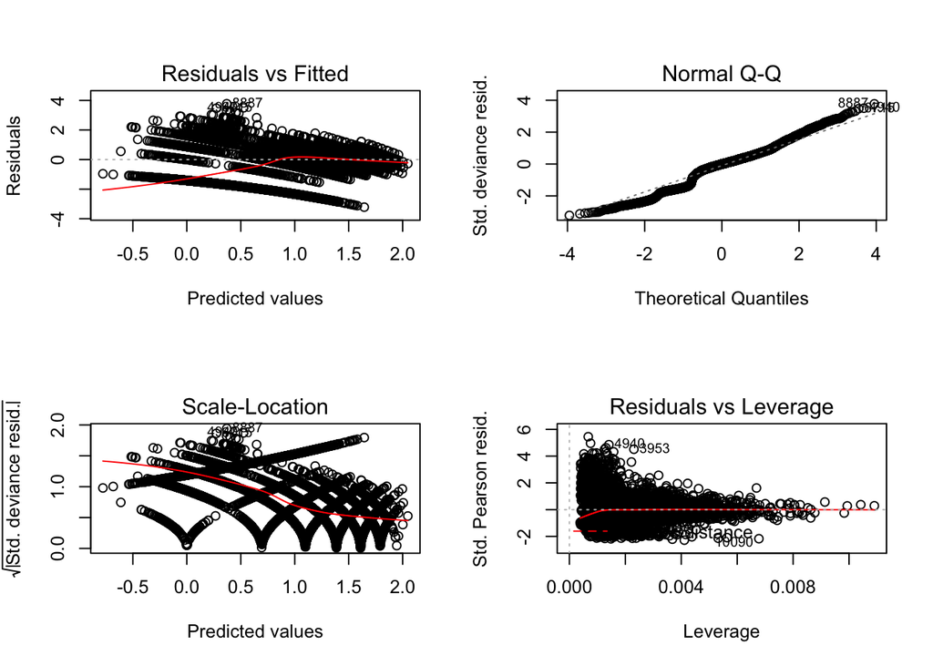

```
##
## Call:  glm.nb(formula = TARGET ~ pH + Alcohol + LabelAppeal + AcidIndex +
##     STARS + VolatileAcidity + Chlorides + FreeSulfurDioxide +
##     TotalSulfurDioxide + Sulphates, data = train_plusiqr15, init.theta = 40823.94516,
##     link = log)
##
## Coefficients:
##        (Intercept)                  pH             Alcohol
##          4.425e-01          -1.083e-02           3.588e-03
##       LabelAppeal1        LabelAppeal2        LabelAppeal3
##          2.340e-01           4.244e-01           5.565e-01
##       LabelAppeal4           AcidIndex              STARS1
##          6.930e-01          -7.935e-02           7.658e-01
##             STARS2              STARS3              STARS4
##          1.084e+00           1.204e+00           1.326e+00
##    VolatileAcidity           Chlorides   FreeSulfurDioxide
##         -2.509e-02          -2.906e-02           7.111e-05
## TotalSulfurDioxide           Sulphates
##          5.301e-05          -9.431e-03
##
## Degrees of Freedom: 12794 Total (i.e. Null);  12778 Residual
## Null Deviance:       22860
## Residual Deviance: 13630     AIC: 45610
```

| Observations | 12795 |
| --- | --- |
| Dependent variable | TARGET |
| Type | Generalized linear model |
| Family | Negative Binomial(40826.99) |
| Link | log |

[output not shown]

|  | Est. | S.E. | z val. | p |
| --- | --- | --- | --- | --- |
| (Intercept) | 0.71 | 0.20 | 3.57 | 0.00 |
| Density | -0.27 | 0.19 | -1.41 | 0.16 |
| pH | -0.01 | 0.01 | -1.43 | 0.15 |
| Alcohol | 0.00 | 0.00 | 2.61 | 0.01 |
| LabelAppeal1 | 0.23 | 0.04 | 6.16 | 0.00 |
| LabelAppeal2 | 0.42 | 0.04 | 11.45 | 0.00 |
| LabelAppeal3 | 0.56 | 0.04 | 14.76 | 0.00 |
| LabelAppeal4 | 0.69 | 0.04 | 16.34 | 0.00 |
| AcidIndex | -0.08 | 0.00 | -17.49 | 0.00 |
| STARS1 | 0.77 | 0.02 | 39.18 | 0.00 |
| STARS2 | 1.08 | 0.02 | 59.40 | 0.00 |
| STARS3 | 1.20 | 0.02 | 62.69 | 0.00 |
| STARS4 | 1.33 | 0.02 | 54.51 | 0.00 |
| VolatileAcidity | -0.03 | 0.00 | -5.27 | 0.00 |
| Chlorides | -0.03 | 0.01 | -2.34 | 0.02 |
| FreeSulfurDioxide | 0.00 | 0.00 | 2.85 | 0.00 |
| TotalSulfurDioxide | 0.00 | 0.00 | 3.60 | 0.00 |
| Sulphates | -0.01 | 0.00 | -2.53 | 0.01 |

Standard errors: MLE

```
## $residual.deviance
## [1] 13624.95
##
## $residual.degrees.of.freedom
## [1] 12774
##
## $chisq.p.value
## [1] 9.23207e-08
```

```
## $residual.deviance
## [1] 13626.41
##
## $residual.degrees.of.freedom
## [1] 12777
##
## $chisq.p.value
## [1] 9.73384e-08
```

There is no significant improvement after using `stepAIC` to select the needed predictors.

The reason to use Zero Dispersion Counts model is due to an inflated number of zeros in our counts target.

```
##
## Call:
## zeroinfl(formula = TARGET ~ . | STARS, data = train_imputed, dist = "negbin")
##
## Pearson residuals:
##      Min       1Q   Median       3Q      Max
## -2.35275 -0.53888  0.01424  0.43922  2.83977
##
## Count model coefficients (negbin with log link):
##                      Estimate Std. Error z value Pr(>|z|)
## (Intercept)         9.466e-01  2.038e-01   4.644 3.41e-06 ***
## FixedAcidity        1.793e-04  8.359e-04   0.214   0.8302
## VolatileAcidity    -1.534e-02  6.684e-03  -2.295   0.0217 *
## CitricAcid          1.468e-03  5.990e-03   0.245   0.8064
## ResidualSugar      -6.588e-06  1.540e-04  -0.043   0.9659
## Chlorides          -2.536e-02  1.635e-02  -1.551   0.1209
## FreeSulfurDioxide   3.917e-05  3.437e-05   1.140   0.2545
## TotalSulfurDioxide -1.345e-06  2.181e-05  -0.062   0.9508
## Density            -2.542e-01  1.964e-01  -1.294   0.1955
## pH                  2.297e-03  7.680e-03   0.299   0.7649
## Sulphates          -2.753e-03  5.606e-03  -0.491   0.6233
## Alcohol             6.455e-03  1.389e-03   4.647 3.37e-06 ***
## LabelAppeal-1       3.730e-01  3.909e-02   9.544  < 2e-16 ***
## LabelAppeal0        6.433e-01  3.822e-02  16.830  < 2e-16 ***
## LabelAppeal1        8.284e-01  3.897e-02  21.259  < 2e-16 ***
## LabelAppeal2        9.843e-01  4.369e-02  22.530  < 2e-16 ***
## AcidIndex          -3.108e-02  4.989e-03  -6.230 4.65e-10 ***
## STARS1              4.840e-02  2.110e-02   2.294   0.0218 *
## STARS2              1.660e-01  1.959e-02   8.477  < 2e-16 ***
## STARS3              2.721e-01  2.060e-02  13.209  < 2e-16 ***
## STARS4              3.728e-01  2.558e-02  14.574  < 2e-16 ***
## Log(theta)          1.398e+01  1.000e+01   1.397   0.1624
##
## Zero-inflation model coefficients (binomial with logit link):
##              Estimate Std. Error z value Pr(>|z|)
## (Intercept)   0.34125    0.03694   9.237   <2e-16 ***
## STARS1       -1.98755    0.06738 -29.499   <2e-16 ***
## STARS2      -10.91246         NA      NA       NA
## STARS3      -20.00076  395.01851  -0.051    0.960
## STARS4      -19.99996  750.68706  -0.027    0.979
## ---
## Signif. codes:  0 '***' 0.001 '**' 0.01 '*' 0.05 '.' 0.1 ' ' 1
##
## Theta = 1173390.2283
## Number of iterations in BFGS optimization: 56
## Log-likelihood: -2.078e+04 on 27 Df
```

# Evaluation

Assessing the fit of a count regression model is not necessarily straightforward; often we just look at residuals, which invariably contain patterns of some form due to the discrete nature of the observations, or we plot observed versus fitted values as a scatter plot.

Kleiber and Zeileis (2016) https://arxiv.org/abs/1605.01311 proposes `rootogram` as an improved approach to the assessment of fit of a count regression model. The paper is illustrated using R and the authors’ countreg package.

Rootograms are calculated using the rootogram() function. You can provide the observed and expected (given the model) counts as arguments to rootogram() or, most usefully for our purposes, a fitted count model object from which the relevant values will be extracted. rootogram() knows about glm, gam, gamlss, hurdle, and zeroinfl objects at the time of writing.

Three different kinds of rootograms are discussed in the paper

- Standing,
- Hanging, and
- Suspended.

Kleiber and Zeileis (2016) recommend hanging or suspended rootograms. Which type of rootogram is produced is controlled via argument style.

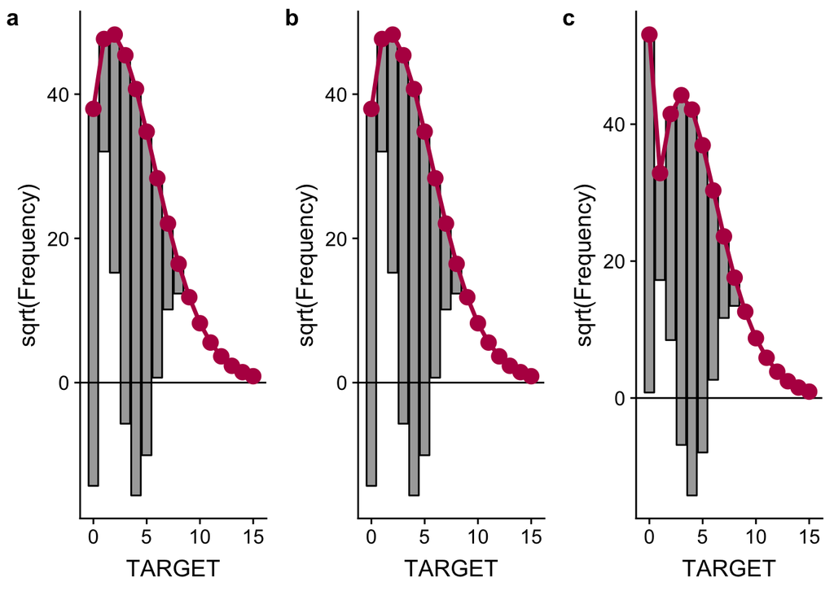

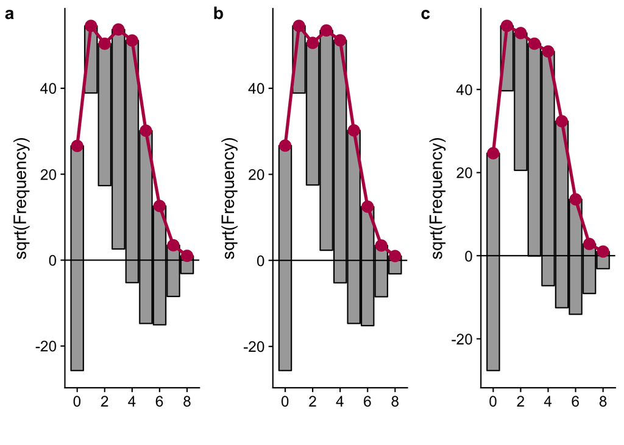

This all indicates that this data should be modeled with a hurdle model.

| Model | AIC | AICc | BIC |
| --- | --- | --- | --- |
| 1 | 45611.92 | 45612.00 | 45775.97 |
| 2 | 45607.38 | 45607.44 | 45749.06 |
| 3 | 41608.87 | 41608.99 | 41810.20 |

# Prediction

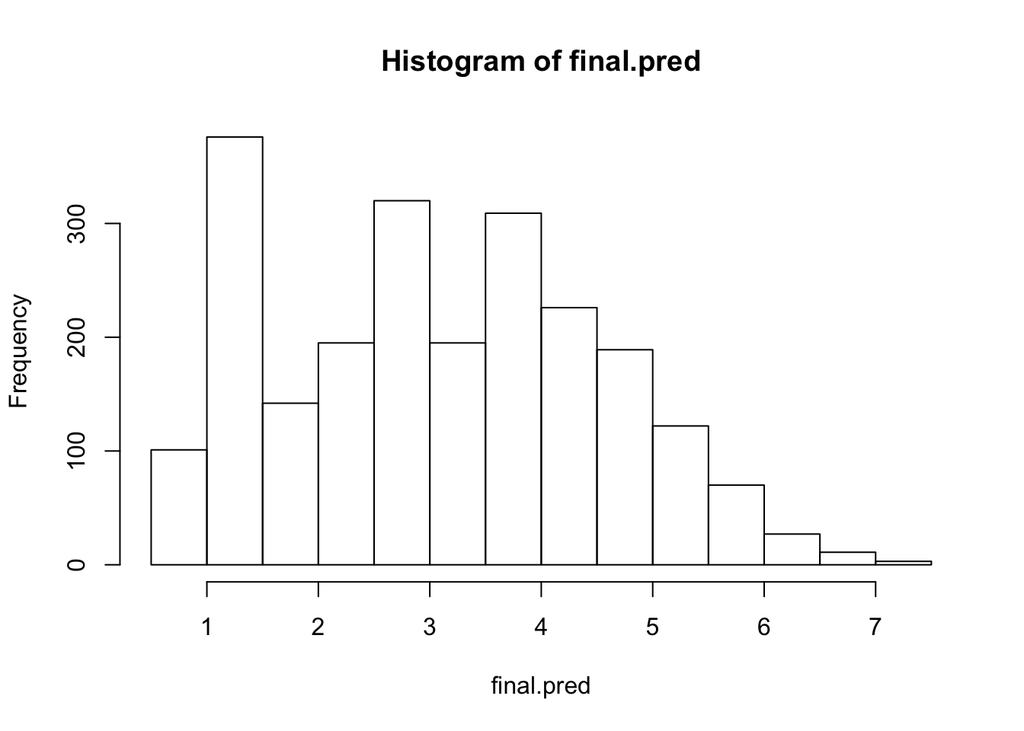

## ref

https://www.fromthebottomoftheheap.net/2016/06/07/rootograms/